# COMPSCIX 415.2 Homework 4

James Harrison

2/24/2018

```r
library(nycflights13)
library(tidyverse)
```

# Homework 4

### Section 5.6.7: #2, #4, #5 and #6 only

2. We could write it using group by tailnum, then summarize and use the sum of the distance to equal n.

```r
not_cancelled <- flights %>%
  filter(!is.na(dep_delay), !is.na(arr_delay))

not_cancelled %>% count(tailnum, wt = distance)
```

```
## # A tibble: 4,037 x 2
##    tailnum      n
##    <chr>    <dbl>
##  1 D942DN    3418
##  2 N0EGMQ  239143
##  3 N10156  109664
##  4 N102UW   25722
##  5 N103US   24619
##  6 N104UW   24616
##  7 N10575  139903
##  8 N105UW   23618
##  9 N107US   21677
## 10 N108UW   32070
## # ... with 4,027 more rows
```

```r
not_cancelled <- flights %>%
  filter(!is.na(dep_delay), !is.na(arr_delay))

not_cancelled %>%
  group_by(tailnum) %>%
  summarise(
           n = sum(distance)
          )
```

```
## # A tibble: 4,037 x 2
##    tailnum      n
##    <chr>    <dbl>
##  1 D942DN    3418
##  2 N0EGMQ  239143
##  3 N10156  109664
##  4 N102UW   25722
##  5 N103US   24619
##  6 N104UW   24616
##  7 N10575  139903
##  8 N105UW   23618
##  9 N107US   21677
## 10 N108UW   32070
## # ... with 4,027 more rows
```

4. Cancelled flights to average delay - yes there is a correlation between the longer delays and more cancelled flights.

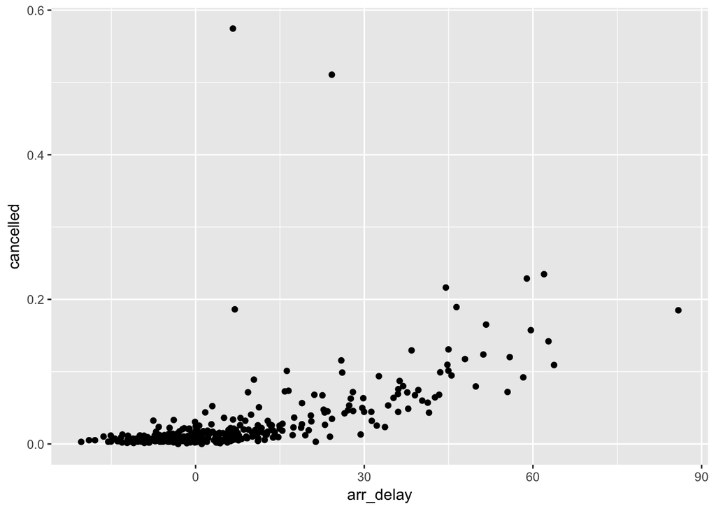

```r
cancelled <- flights %>%
  filter(is.na(dep_delay), is.na(arr_delay))

  #daily <- group_by(flights, year, month) #%>%
 # filter(is.na(dep_delay), is.na(arr_delay))
#(per_month   <- summarise(daily, flights = n(), delay = mean(arr_delay)))


#by_month <- group_by(flights, year, month)
#summarize(by_month,
                        # count = n(),
                        # arr_delay = mean(arr_delay, na.rm = TRUE),
                        # dep_delay = mean(dep_delay, na.rm = TRUE),
                        # )

james_flights <- flights %>%
  mutate(cancel = (is.na(dep_delay) | is.na(arr_delay))) %>%
  group_by( year, month, day)%>%
  summarize(
      arr_delay = mean(arr_delay, na.rm = TRUE),
      cancelled = mean(cancel)
  )
  ggplot(james_flights, aes(x=arr_delay, y=cancelled))+
    geom_point()
```

5. F9 has the worst delays, but if we add in the destination as well United to STL is the worst route.

```r
new_flights <- flights %>% group_by(carrier, dest) %>% summarise(n(), arr_delay = mean(arr_delay, na.rm = TRUE))
arrange(new_flights, desc(arr_delay))
```

```
## # A tibble: 314 x 4
## # Groups:   carrier [16]
##    carrier dest  `n()` arr_delay
##    <chr>   <chr> <int>     <dbl>
##  1 UA      STL       2     110
##  2 OO      ORD       1     107
##  3 OO      DTW       2      68.5
##  4 UA      RDU       1      56.0
##  5 EV      CAE     113      42.8
##  6 EV      TYS     323      41.2
##  7 EV      PBI       6      40.7
##  8 EV      TUL     315      33.7
##  9 EV      OKC     346      30.6
## 10 UA      JAC      23      29.9
## # ... with 304 more rows
```

6. If sort is on it will sort in descending value of N - could be useful when trying to see the greatest number of delays by carrier for example.

### Section 10.5: #1, #2, #3 and #6 only

1. When printing a tibble only prints the first ten rows and each column prints both name and type.
2. Tibbles let you quickly pull out data by name with tools like $ and [|]. In the example you can quickly see variable x in df using $. Tibbles are also more strict - they won’t do partial matching and warn you if the column you’re accessing doesn’t exist.
3. Use the $ tool - can grab variables by name.
4. The tibble.max_extra_cols controls extra columns printed in a tibble.

### Section 12.3.3: #2, #3 and #4 only

2. You need the numbers in quotations.
3. It fails because it has multiple values for one type - philip woods has two ages - if we add another column for age 1 and age 2 it could work.
4. We need to gather the tibble - the variables are the pregnant true false, a gender, and a count of how many are in each category.

```r
preg <- tribble(
  ~pregnant, ~male, ~female,
  "yes",     NA,    10,
  "no",      20,    12
)

gather(preg, gender, count, male, female)
```

```
## # A tibble: 4 x 3
##   pregnant gender count
##   <chr>    <chr>  <dbl>
## 1 yes      male    NA
## 2 no       male    20.0
## 3 yes      female  10.0
## 4 no       female  12.0
```

### Section 12.4.3: #1 and #2 only

1. In separate() - extra can be used to control what happens when separating a character vector with extra values- you can warn, drop, or merge the extra values. Fill can be used in the opposite case when there aren’t enough values - you can warn, fill right with missing values or fill left with missing values.
2. Remove gets rid of the original input column you’re working with - you’d keep it as false if you want to maintain that column as well.

### Additional Baby Names Questions

Load:

```r
baby_n <- read.table("/Users/james.harrison/compscix-415-2-assignments/baby_names.txt",
                        header = TRUE,
                        sep = "|")
glimpse(baby_n)
```

```
## Observations: 30,000
## Variables: 5
## $ year <int> 1880, 1880, 1880, 1880, 1880, 1880, 1880, 1880, 1880, 188...
## $ sex  <fct> F, F, F, F, F, F, F, F, F, F, F, F, F, F, F, F, F, F, F, ...
## $ name <fct> Mary, Anna, Emma, Elizabeth, Minnie, Margaret, Ida, Alice...
## $ n    <int> 7065, 2604, 2003, 1939, 1746, 1578, 1472, 1414, 1320, 128...
## $ prop <dbl> 0.072384329, 0.026679234, 0.020521700, 0.019865989, 0.017...
```

Export:

```r
saveRDS(baby_n, file = "/Users/james.harrison/compscix-415-2-assignments/baby_names.rds")
```

Re-import:

```r
baby_n2 <- readRDS(file = "/Users/james.harrison/compscix-415-2-assignments/baby_names.rds")
glimpse(baby_n2)
```

```
## Observations: 30,000
## Variables: 5
## $ year <int> 1880, 1880, 1880, 1880, 1880, 1880, 1880, 1880, 1880, 188...
## $ sex  <fct> F, F, F, F, F, F, F, F, F, F, F, F, F, F, F, F, F, F, F, ...
## $ name <fct> Mary, Anna, Emma, Elizabeth, Minnie, Margaret, Ida, Alice...
## $ n    <int> 7065, 2604, 2003, 1939, 1746, 1578, 1472, 1414, 1320, 128...
## $ prop <dbl> 0.072384329, 0.026679234, 0.020521700, 0.019865989, 0.017...
```